# King County Streams Water Quality Index

Ask, Prepare, Process

MG

Modified: 2023-10-19

# 1 Ask: Business Task Statement

- How does WQI change over the years? Select a few stations with long recording logs and answer the question, whether the water quality was better in the past, or is better now, or is worse?
- How does WQI change depending on the geographical location? Select a few stations at different geographical locations and compare WQI. Is there any pattern such as more densely populated areas have WQI worse than sparsely populated areas? Does any of the areas such as north/south/east/west have cleaner water over the others?

# 2 Prepare: Data Source

The source of data is [1]. The data is published by King County Washington State.

## 2.1 Data Organization

Data is contained in a single csv file named: kc_swqi.csv.

## 2.2 Data Credibility

The data is provided by the government entity and I assume they follow the standards for collecting and publishing credible data.

## 2.3 Data Bias

The presence of bias in the data is a challenging question to address. However, given that the data source is a governmental agency, it is reasonable to expect that they have taken measures to minimize any potential bias.

## 2.4 License and Attribution

Public Domain [1].

# 3 Process: Data Wrangling

I added one column ‘Month.new’ where ‘WholeYear’ was replaced with 13 in LibreOffice Calc, so months are represented as numbers 1-12 and the whole year is represented as the number 13. I removed the column ‘Month’ and renamed ‘Month.new’ to ‘Month’.

The number of rows is 348220 organized in 11 columns but the column “GeoLocation” has no values so it will be removed.

```
## <class 'pandas.core.frame.DataFrame'>
## RangeIndex: 348220 entries, 0 to 348219
## Data columns (total 11 columns):
##  #   Column            Non-Null Count   Dtype
## ---  ------            --------------   -----
##  0   Locator           348220 non-null  object
##  1   WaterYear         348220 non-null  int64
##  2   WQI               319698 non-null  float64
##  3   Month             348220 non-null  int64
##  4   ParameterGroup    348220 non-null  object
##  5   lng               348220 non-null  float64
##  6   lat               348220 non-null  float64
##  7   GeoLocation       0 non-null       float64
##  8   MostRecentSample  348220 non-null  bool
##  9   SiteName          348220 non-null  object
##  10  StreamName        348220 non-null  object
## dtypes: bool(1), float64(4), int64(2), object(4)
## memory usage: 26.9+ MB
```

## 3.1 Incorrect Data Types

Automatically assigned data types are reasonable so there was no need for any correction.

## 3.2 Missing Data

### 3.2.1 GeoLocation

It seems that WQI has missing 28522, i.e., 8.2% values and GeoLocation 348220, i.e., 100%.

I removed the GeoLocation column as it has no values.

### 3.2.2 WQI NaN

This study is about WQI, so having rows that have missing WQI values is pointless. They might be useful for analysis which stations have missing WQI readings. I removed rows with missing WQI values.

## 3.3 Descriptive Statistics

The number of rows is 319698 organized in 10 columns.

```
## <class 'pandas.core.frame.DataFrame'>
## RangeIndex: 319698 entries, 0 to 319697
## Data columns (total 10 columns):
##  #   Column            Non-Null Count   Dtype
## ---  ------            --------------   -----
##  0   Locator           319698 non-null  object
##  1   WaterYear         319698 non-null  int64
##  2   WQI               319698 non-null  float64
##  3   Month             319698 non-null  int64
##  4   ParameterGroup    319698 non-null  object
##  5   lng               319698 non-null  float64
##  6   lat               319698 non-null  float64
##  7   MostRecentSample  319698 non-null  bool
##  8   SiteName          319698 non-null  object
##  9   StreamName        319698 non-null  object
## dtypes: bool(1), float64(3), int64(2), object(4)
## memory usage: 22.3+ MB
```

```
##        Locator      WaterYear            WQI          Month ParameterGroup  \
## count   319698  319698.000000  319698.000000  319698.000000         319698
## unique      78            NaN            NaN            NaN             13
## top       3106            NaN            NaN            NaN    Temperature
## freq      6984            NaN            NaN            NaN          28819
## mean       NaN    2003.902436      80.893743       6.984223            NaN
## std        NaN      13.302727      25.567113       3.750710            NaN
## min        NaN    1970.000000       0.000000       1.000000            NaN
## 25%        NaN    1994.000000      75.390000       4.000000            NaN
## 50%        NaN    2005.000000      90.860000       7.000000            NaN
## 75%        NaN    2016.000000      98.320000      10.000000            NaN
## max        NaN    2023.000000     229.650000      13.000000            NaN
##
##                   lng            lat MostRecentSample  \
## count   319698.000000  319698.000000           319698
## unique            NaN            NaN                2
## top               NaN            NaN            False
## freq              NaN            NaN           318798
## mean      -122.153209      47.566108              NaN
## std          0.143699       0.159589              NaN
## min       -122.508600      47.176100              NaN
## 25%       -122.233900      47.465500              NaN
## 50%       -122.166400      47.601100              NaN
## 75%       -122.069600      47.705400              NaN
## max       -121.372200      47.811400              NaN
##
##                            SiteName StreamName
## count                        319698     319698
## unique                           78         60
## top     Green River at Starfire Way      Green
## freq                           6984      25483
## mean                            NaN        NaN
## std                             NaN        NaN
## min                             NaN        NaN
## 25%                             NaN        NaN
## 50%                             NaN        NaN
## 75%                             NaN        NaN
## max                             NaN        NaN
```

### 3.3.1 Categorical and Numerical

| No. | Categorical Variables | Numerical Variables |
| --- | --- | --- |
| 1. | Locator | WaterYear |
| 2. | Month | WQI |
| 3. | ParameterGroup | lng |
| 4. | MostRecentSample | lat |
| 5. | SiteName |  |
| 6. | StreamName |  |

```
## Cat.:  Locator  unique values count= 78  min= 3  max= 13
## Cat.:  ParameterGroup  unique values count= 13  min= 2  max= 22
## Cat.:  SiteName  unique values count= 78  min= 13  max= 49
## Cat.:  StreamName  unique values count= 60  min= 3  max= 24
```

### 3.3.2 Data Ranges

WQI seems the most problematic as some values are out of range.

#### 3.3.2.1 Water Quality Index (WQI)

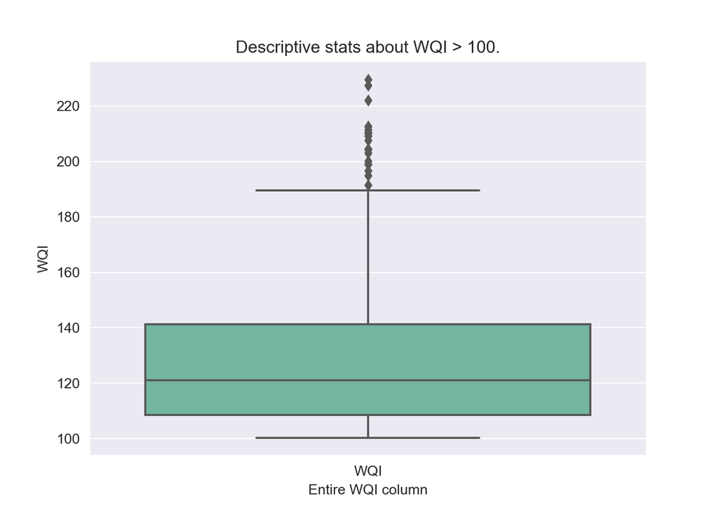

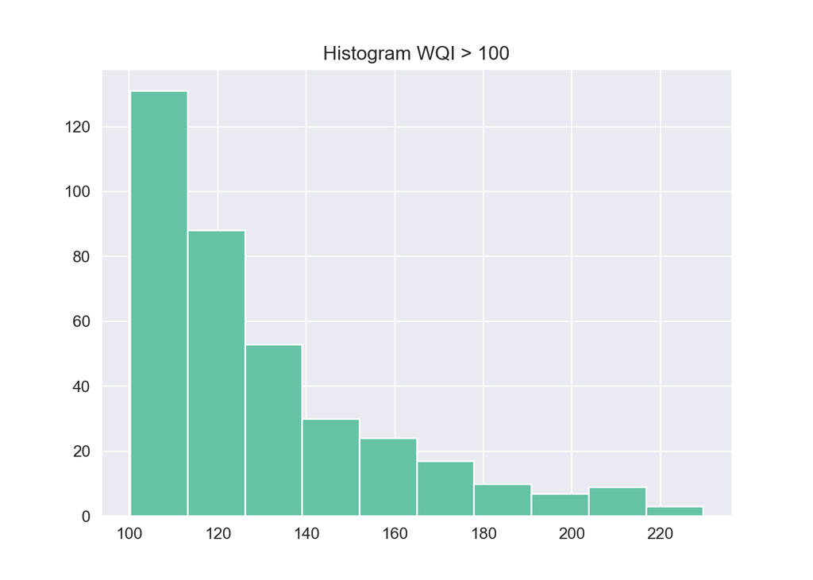

WQI stratification according to [2] is as follows:

- scores 80+, *low concern* because did not fail water quality standards or guidelines
- scores 40 to 80, *modern concern*
- scores below 40, *high concern*

I decided to bin observations according to WQI scores as specified in [2] and added the column *WQI_binned* with values:

- 1 indicating *high concern*, WQI $<$ 40,
- 2 indicating *modern concern*, 40 $\le$ WQI $<$ 80,
- 3 indicating *low concern*, WQI $\ge$ 80.

#### 3.3.2.2 Locator

It seems that it is an identifier for a measuring station.

```
## ['311', '317', '321', '322', '430', '434', '438', '440', '442', '444', '446', '0450CC', '470', '474', '478', '484', '0484A', '486', '631', '632', '3106', 'A315', 'A319', 'A320', 'A432', 'A438', 'A456', 'A499', 'A617', 'A620', 'A631', 'A670', 'A680', 'A685', 'A687', 'A690', 'AMES_1', 'B319', 'B484…
```

#### 3.3.2.3 ParameterGroup

As explained in [3]

> “The Water Quality Index (WQI) is a general method used to report water quality data for many parameters as a single number or score. Using a WQI helps to compare water quality for different sampling locations over time. WQIs have been widely used in many fields of water quality, from drinking water to watershed management, since the 1800s. Horton (1965) developed the first parameter based numerical WQI in 1965 to evaluate the health of rivers. Horton’s method integrated ten commonly monitored water quality parameters.

> WQI methods follow three steps. First, water quality data is collected. Next, concentrations or measurements of parameters are converted to subindex scores on a common scale. Scoring metrics are typically based on water quality standards and technical guidelines. Finally, scores are aggregated into a single number.”

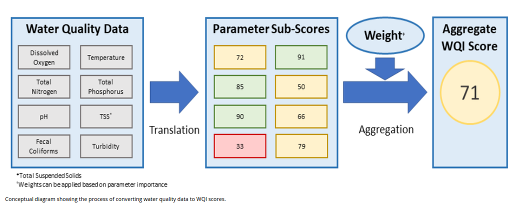

WQI scores explained

The further explanation on the website [3]:

> “Washington Department of Ecology (Ecology) adapted an index developed by the Environmental Protection Agency (EPA) Region 10. Ecology adjusted the scoring metrics to reflect local water quality standards and/or guidelines. They also modified the nutrient scoring metrics to better reflect conditions in Puget Sound lowland streams.”

> “King County is using Ecology’s Puget Sound lowland stream version of the WQI. The WQI developed by Ecology ranges from 0-100: the higher the number, the higher the water quality. It includes eight parameters: temperature, dissolved oxygen, pH, fecal coliform bacteria, total nitrogen, total phosphorus, total suspended sediment, and turbidity (Hallock, 2002). The scoring metrics for parameters are based on regulatory standards. Those levels are defined by criteria in Washington’s Water Quality Standards, WAC 173-201A. Nutrient and sediment measures have no set standard. Therefore, results for those metrics are expressed relative to guidelines for this ecoregion. Results from the eight parameters are aggregated over time to produce a single score for each monitoring site. In general, stations scoring 80 and above did not fail water quality standards or guidelines and are of”low concern”. Scores 40 to 80 indicate “moderate concern”, and water quality at stations with scores below 40 are of “high concern.” ”

It seems that that the idea behind the column ‘ParameterGroup’ is to measure several parameters on a monthly basis with ‘MonthlyScore’ and once per year ‘AnnualScore’ per Locator. I understand that ‘AnnualScore’ is calculated based on monthly scores (maybe as a mean) and ‘MonthlyScore’ is weighted sum of monthly parameters.

```
##        Locator  WaterYear    WQI  Month          ParameterGroup
## 56504   0450CC       2007  59.76      7                 Penalty
## 56505   0450CC       2007  37.35      7         DissolvedOxygen
## 56506   0450CC       2007  92.69      7                      pH
## 56507   0450CC       2007  54.63      7             Temperature
## 56508   0450CC       2007  72.72      7          Total.Nitrogen
## 56509   0450CC       2007  70.39      7        Total.Phosphorus
## 56510   0450CC       2007  99.25      7  Total.Suspended.Solids
## 56511   0450CC       2007  99.25      7                Sediment
## 56512   0450CC       2007  70.39      7                Nutrient
## 276034  0450CC       2007  24.55      7            MonthlyScore
## 56513   0450CC       2007  20.51      8                 Penalty
## 56514   0450CC       2007  69.24      8         DissolvedOxygen
## 56515   0450CC       2007  95.02      8                      pH
## 56516   0450CC       2007  71.01      8             Temperature
## 56517   0450CC       2007  80.60      8          Total.Nitrogen
```

#### 3.3.2.4 Relations Among Locator, lng, lat, and SiteName, and StreamName

##### StreamName and SiteName

The StreamName can be assigned to many SiteName.

```
##      Locator       lng      lat                                   SiteName  \
## 0        311 -122.2479  47.4655                  Green River at Interurban
## 858     3106 -122.2490  47.4678                Green River at Starfire Way
## 958     A319 -122.1759  47.3021  Green River at SE Auburn-Black Diamond Rd
## 1434    B319 -122.0553  47.2824                Green River at 212th Way SE
##
##      StreamName
## 0         Green
## 858       Green
## 958       Green
## 1434      Green
```

For instance, the stream named Green has 4 corresponding sites.

##### Uniqueness of Locator, lat, lng, and SiteName

It seems that ‘Locator’ is an identifier for the ‘SiteName’ that has unique ‘lat’ and ‘lng’.

```
## Are there any duplicates, given Locator, lng, lat, and SiteName? False
```

```
## Are there duplicates in lng and lat?  False
```

```
## Are there duplicates in Locator?  False
```

```
## Are there duplicates in  SiteName?  False
```

# 4 Final Version

At this point I consider the data is clean enough and can be used for the next stage, i.e., analysis. I have removed some rows with missing WQI values. I have removed one column ‘GeoLocation’ and added a new column ‘WQI_binned’ to represent strata of WQI according to Washington recommendations.

|  | Current Dataset | Original Dataset | Original - Current (Diff) |
| --- | --- | --- | --- |
| Rows count | 319326 | 348220 | 28894 |
| Cols count | 11 | 11 | 0 |

The data structure is as follows:

```
## <class 'pandas.core.frame.DataFrame'>
## Index: 319326 entries, 0 to 319697
## Data columns (total 11 columns):
##  #   Column            Non-Null Count   Dtype
## ---  ------            --------------   -----
##  0   Locator           319326 non-null  object
##  1   WaterYear         319326 non-null  int64
##  2   WQI               319326 non-null  float64
##  3   Month             319326 non-null  int64
##  4   ParameterGroup    319326 non-null  object
##  5   lng               319326 non-null  float64
##  6   lat               319326 non-null  float64
##  7   MostRecentSample  319326 non-null  bool
##  8   SiteName          319326 non-null  object
##  9   StreamName        319326 non-null  object
##  10  WQI_binned        319326 non-null  int32
## dtypes: bool(1), float64(3), int32(1), int64(2), object(4)
## memory usage: 25.9+ MB
```

```
## WARNING: File exists in location:  input/kc_swqi_proc.csv  No write ...
```

# 5 Notes

- There are many WQI values missing and some are $> 100$. This might be worth to investigate. WQI values $> 100$ might be because a single WQI value is calculated from several parameters and values of those parameters and/or weights might not be normalized.

# References

[1]

K. County, “King County Streams Water Quality Index.” King County Washington State, May 2023. Available: https://data.kingcounty.gov/Environment-Waste-Management/King-County-Streams-Water-Quality-Index/ww4k-7bef

[2]

K. County, “Water Quality Index for Streams and Rivers.” King County Washington State, 2022. Available: https://green2.kingcounty.gov/streamsdata/WQI.aspx

[3]

K. County, “Water Quality Index Background.” King County Washington State, 2023. Available: https://kingcounty.gov/services/environment/watersheds/streams-data/water-quality-index/WQIBackGround.aspx